# Practical Machine Learning Project

Thomas Yue

March 19, 2015

# Background

Using devices such as Jawbone Up, Nike FuelBand, and Fitbit it is now possible to collect a large amount of data about personal activity relatively inexpensively. The data was collected from accelerometers on the belt, forearm, arm, and dumbell of 6 participants. They were asked to perform barbell lifts correctly and incorrectly in 5 different ways. More information is available from the website here: http://groupware.les.inf.puc-rio.br/har (see the section on the Weight Lifting Exercise Dataset). "

# Data source

The data for this project come from this source: http://groupware.les.inf.puc-rio.br/har. The training data were obtained from: https://d396qusza40orc.cloudfront.net/predmachlearn/pml-training.csv. The test data were obtained from: https://d396qusza40orc.cloudfront.net/predmachlearn/pml-testing.csv.

# Required packages

```r
set.seed(1234)
library(ggplot2)
library(gridExtra)
library(caret)
library(randomForest) #Random forest for classification and regression
library(rpart) # Regressive Partitioning and Regression trees
library(rpart.plot) # Decision Tree plot
```

# Data perprocessing

```r
#download.file("http://d396qusza40orc.cloudfront.net/predmachlearn/pml-training.csv", "trainingData.csv")
#download.file("http://d396qusza40orc.cloudfront.net/predmachlearn/pml-testing.csv", "testingData.csv")

trainingData  <- read.csv("trainingData.csv", na.strings = c("NA","#DIV/0!", ""))
testingData   <- read.csv('testingData.csv', na.strings = c("NA","#DIV/0!", ""))

trainingData  <- trainingData[,colSums(is.na(trainingData)) == 0]
testingData   <- testingData[,colSums(is.na(testingData)) == 0]

#pick out the revelant columns only. Delete the column for user_name, raw_timestamp_part_1, raw_timestamp_part_,2 cvtd_timestamp, new_window, and  num_window (columns 1 to 7).

trainingData  <- trainingData[,-c(1:7)]
testingData   <- testingData[,-c(1:7)]
summary(trainingData)
```

```
##    roll_belt        pitch_belt          yaw_belt       total_accel_belt
##  Min.   :-28.90   Min.   :-55.8000   Min.   :-180.00   Min.   : 0.00
##  1st Qu.:  1.10   1st Qu.:  1.7600   1st Qu.: -88.30   1st Qu.: 3.00
##  Median :113.00   Median :  5.2800   Median : -13.00   Median :17.00
##  Mean   : 64.41   Mean   :  0.3053   Mean   : -11.21   Mean   :11.31
##  3rd Qu.:123.00   3rd Qu.: 14.9000   3rd Qu.:  12.90   3rd Qu.:18.00
##  Max.   :162.00   Max.   : 60.3000   Max.   : 179.00   Max.   :29.00
##   gyros_belt_x        gyros_belt_y       gyros_belt_z
##  Min.   :-1.040000   Min.   :-0.64000   Min.   :-1.4600
##  1st Qu.:-0.030000   1st Qu.: 0.00000   1st Qu.:-0.2000
##  Median : 0.030000   Median : 0.02000   Median :-0.1000
##  Mean   :-0.005592   Mean   : 0.03959   Mean   :-0.1305
##  3rd Qu.: 0.110000   3rd Qu.: 0.11000   3rd Qu.:-0.0200
##  Max.   : 2.220000   Max.   : 0.64000   Max.   : 1.6200
##   accel_belt_x       accel_belt_y     accel_belt_z     magnet_belt_x
##  Min.   :-120.000   Min.   :-69.00   Min.   :-275.00   Min.   :-52.0
##  1st Qu.: -21.000   1st Qu.:  3.00   1st Qu.:-162.00   1st Qu.:  9.0
##  Median : -15.000   Median : 35.00   Median :-152.00   Median : 35.0
##  Mean   :  -5.595   Mean   : 30.15   Mean   : -72.59   Mean   : 55.6
##  3rd Qu.:  -5.000   3rd Qu.: 61.00   3rd Qu.:  27.00   3rd Qu.: 59.0
##  Max.   :  85.000   Max.   :164.00   Max.   : 105.00   Max.   :485.0
##  magnet_belt_y   magnet_belt_z       roll_arm         pitch_arm
##  Min.   :354.0   Min.   :-623.0   Min.   :-180.00   Min.   :-88.800
##  1st Qu.:581.0   1st Qu.:-375.0   1st Qu.: -31.77   1st Qu.:-25.900
##  Median :601.0   Median :-320.0   Median :   0.00   Median :  0.000
##  Mean   :593.7   Mean   :-345.5   Mean   :  17.83   Mean   : -4.612
##  3rd Qu.:610.0   3rd Qu.:-306.0   3rd Qu.:  77.30   3rd Qu.: 11.200
##  Max.   :673.0   Max.   : 293.0   Max.   : 180.00   Max.   : 88.500
##     yaw_arm          total_accel_arm  gyros_arm_x        gyros_arm_y
##  Min.   :-180.0000   Min.   : 1.00   Min.   :-6.37000   Min.   :-3.4400
##  1st Qu.: -43.1000   1st Qu.:17.00   1st Qu.:-1.33000   1st Qu.:-0.8000
##  Median :   0.0000   Median :27.00   Median : 0.08000   Median :-0.2400
##  Mean   :  -0.6188   Mean   :25.51   Mean   : 0.04277   Mean   :-0.2571
##  3rd Qu.:  45.8750   3rd Qu.:33.00   3rd Qu.: 1.57000   3rd Qu.: 0.1400
##  Max.   : 180.0000   Max.   :66.00   Max.   : 4.87000   Max.   : 2.8400
##   gyros_arm_z       accel_arm_x       accel_arm_y      accel_arm_z
##  Min.   :-2.3300   Min.   :-404.00   Min.   :-318.0   Min.   :-636.00
##  1st Qu.:-0.0700   1st Qu.:-242.00   1st Qu.: -54.0   1st Qu.:-143.00
##  Median : 0.2300   Median : -44.00   Median :  14.0   Median : -47.00
##  Mean   : 0.2695   Mean   : -60.24   Mean   :  32.6   Mean   : -71.25
```

[output cut: 50 more lines]

```
##  Max.   :311.00000   Max.   :231.0000   Max.   : 477.00   Max.   : 923.0
##  accel_forearm_z   magnet_forearm_x  magnet_forearm_y magnet_forearm_z
##  Min.   :-446.00   Min.   :-1280.0   Min.   :-896.0   Min.   :-973.0
##  1st Qu.:-182.00   1st Qu.: -616.0   1st Qu.:   2.0   1st Qu.: 191.0
##  Median : -39.00   Median : -378.0   Median : 591.0   Median : 511.0
##  Mean   : -55.29   Mean   : -312.6   Mean   : 380.1   Mean   : 393.6
##  3rd Qu.:  26.00   3rd Qu.:  -73.0   3rd Qu.: 737.0   3rd Qu.: 653.0
##  Max.   : 291.00   Max.   :  672.0   Max.   :1480.0   Max.   :1090.0
##  classe
##  A:5580
##  B:3797
##  C:3422
##  D:3216
##  E:3607
##
```

```r
summary(testingData)
```

```
##    roll_belt          pitch_belt         yaw_belt      total_accel_belt
##  Min.   : -5.9200   Min.   :-41.600   Min.   :-93.70   Min.   : 2.00
##  1st Qu.:  0.9075   1st Qu.:  3.013   1st Qu.:-88.62   1st Qu.: 3.00
##  Median :  1.1100   Median :  4.655   Median :-87.85   Median : 4.00
##  Mean   : 31.3055   Mean   :  5.824   Mean   :-59.30   Mean   : 7.55
##  3rd Qu.: 32.5050   3rd Qu.:  6.135   3rd Qu.:-63.50   3rd Qu.: 8.00
##  Max.   :129.0000   Max.   : 27.800   Max.   :162.00   Max.   :21.00
##   gyros_belt_x     gyros_belt_y     gyros_belt_z      accel_belt_x
##  Min.   :-0.500   Min.   :-0.050   Min.   :-0.4800   Min.   :-48.00
##  1st Qu.:-0.070   1st Qu.:-0.005   1st Qu.:-0.1375   1st Qu.:-19.00
##  Median : 0.020   Median : 0.000   Median :-0.0250   Median :-13.00
##  Mean   :-0.045   Mean   : 0.010   Mean   :-0.1005   Mean   :-13.50
##  3rd Qu.: 0.070   3rd Qu.: 0.020   3rd Qu.: 0.0000   3rd Qu.: -8.75
##  Max.   : 0.240   Max.   : 0.110   Max.   : 0.0500   Max.   : 46.00
##   accel_belt_y     accel_belt_z     magnet_belt_x    magnet_belt_y
##  Min.   :-16.00   Min.   :-187.00   Min.   :-13.00   Min.   :566.0
##  1st Qu.:  2.00   1st Qu.: -24.00   1st Qu.:  5.50   1st Qu.:578.5
##  Median :  4.50   Median :  27.00   Median : 33.50   Median :600.5
##  Mean   : 18.35   Mean   : -17.60   Mean   : 35.15   Mean   :601.5
##  3rd Qu.: 25.50   3rd Qu.:  38.25   3rd Qu.: 46.25   3rd Qu.:631.2
##  Max.   : 72.00   Max.   :  49.00   Max.   :169.00   Max.   :638.0
##  magnet_belt_z       roll_arm         pitch_arm          yaw_arm
##  Min.   :-426.0   Min.   :-137.00   Min.   :-63.800   Min.   :-167.00
##  1st Qu.:-398.5   1st Qu.:   0.00   1st Qu.: -9.188   1st Qu.: -60.15
##  Median :-313.5   Median :   0.00   Median :  0.000   Median :   0.00
##  Mean   :-346.9   Mean   :  16.42   Mean   : -3.950   Mean   :  -2.80
##  3rd Qu.:-305.0   3rd Qu.:  71.53   3rd Qu.:  3.465   3rd Qu.:  25.50
##  Max.   :-291.0   Max.   : 152.00   Max.   : 55.000   Max.   : 178.00
##  total_accel_arm  gyros_arm_x      gyros_arm_y       gyros_arm_z
##  Min.   : 3.00   Min.   :-3.710   Min.   :-2.0900   Min.   :-0.6900
##  1st Qu.:20.25   1st Qu.:-0.645   1st Qu.:-0.6350   1st Qu.:-0.1800
##  Median :29.50   Median : 0.020   Median :-0.0400   Median :-0.0250
##  Mean   :26.40   Mean   : 0.077   Mean   :-0.1595   Mean   : 0.1205
##  3rd Qu.:33.25   3rd Qu.: 1.248   3rd Qu.: 0.2175   3rd Qu.: 0.5650
##  Max.   :44.00   Max.   : 3.660   Max.   : 1.8500   Max.   : 1.1300
##   accel_arm_x      accel_arm_y      accel_arm_z       magnet_arm_x
##  Min.   :-341.0   Min.   :-65.00   Min.   :-404.00   Min.   :-428.00
##  1st Qu.:-277.0   1st Qu.: 52.25   1st Qu.:-128.50   1st Qu.:-373.75
##  Median :-194.5   Median :112.00   Median : -83.50   Median :-265.00
##  Mean   :-134.6   Mean   :103.10   Mean   : -87.85   Mean   : -38.95
```

[output cut: 43 more lines]

```
##  Max.   :47.00       Max.   : 1.3800   Max.   : 4.2600   Max.   : 1.8000
##  accel_forearm_x  accel_forearm_y  accel_forearm_z  magnet_forearm_x
##  Min.   :-212.0   Min.   :-331.0   Min.   :-282.0   Min.   :-714.0
##  1st Qu.:-114.8   1st Qu.:   8.5   1st Qu.:-199.0   1st Qu.:-427.2
##  Median :  86.0   Median : 138.0   Median :-148.5   Median :-189.5
##  Mean   :  38.8   Mean   : 125.3   Mean   : -93.7   Mean   :-159.2
##  3rd Qu.: 166.2   3rd Qu.: 268.0   3rd Qu.: -31.0   3rd Qu.:  41.5
##  Max.   : 232.0   Max.   : 406.0   Max.   : 179.0   Max.   : 532.0
##  magnet_forearm_y magnet_forearm_z   problem_id
##  Min.   :-787.0   Min.   :-32.0    Min.   : 1.00
##  1st Qu.:-328.8   1st Qu.:275.2    1st Qu.: 5.75
##  Median : 487.0   Median :491.5    Median :10.50
##  Mean   : 191.8   Mean   :460.2    Mean   :10.50
##  3rd Qu.: 720.8   3rd Qu.:661.5    3rd Qu.:15.25
##  Max.   : 800.0   Max.   :884.0    Max.   :20.00
```

# Partition the training data for cross-validation

```r
q  <- createDataPartition(y=trainingData$classe, p=0.75, list=FALSE)
subTrainingData <- trainingData[q, ]
subTestingData  <- trainingData[-q, ]
subTrainingData <- subTrainingData[complete.cases(subTrainingData),]
subTestingData  <- subTestingData[complete.cases(subTestingData),]
head(subTrainingData)
```

```
##   roll_belt pitch_belt yaw_belt total_accel_belt gyros_belt_x gyros_belt_y
## 2      1.41       8.07    -94.4                3         0.02         0.00
## 3      1.42       8.07    -94.4                3         0.00         0.00
## 4      1.48       8.05    -94.4                3         0.02         0.00
## 5      1.48       8.07    -94.4                3         0.02         0.02
## 6      1.45       8.06    -94.4                3         0.02         0.00
## 7      1.42       8.09    -94.4                3         0.02         0.00
##   gyros_belt_z accel_belt_x accel_belt_y accel_belt_z magnet_belt_x
## 2        -0.02          -22            4           22            -7
## 3        -0.02          -20            5           23            -2
## 4        -0.03          -22            3           21            -6
## 5        -0.02          -21            2           24            -6
## 6        -0.02          -21            4           21             0
## 7        -0.02          -22            3           21            -4
##   magnet_belt_y magnet_belt_z roll_arm pitch_arm yaw_arm total_accel_arm
```

[output cut: 69 more lines]

```r
head(subTestingData)
```

```
##    roll_belt pitch_belt yaw_belt total_accel_belt gyros_belt_x
## 1       1.41       8.07    -94.4                3         0.00
## 21      1.60       8.10    -94.4                3         0.02
## 22      1.57       8.09    -94.4                3         0.02
## 23      1.56       8.10    -94.3                3         0.02
## 25      1.53       8.11    -94.4                3         0.03
## 26      1.55       8.09    -94.4                3         0.02
##    gyros_belt_y gyros_belt_z accel_belt_x accel_belt_y accel_belt_z
## 1          0.00        -0.02          -21            4           22
## 21         0.00        -0.02          -20            1           20
## 22         0.02        -0.02          -21            3           21
## 23         0.00        -0.02          -21            4           21
## 25         0.00         0.00          -19            4           21
## 26         0.00         0.00          -21            3           22
##    magnet_belt_x magnet_belt_y magnet_belt_z roll_arm pitch_arm yaw_arm
```

[output cut: 69 more lines]

# Exploratory data analysis

Conduct a preliminary analysis by plotting a histrogram of the classe variable.

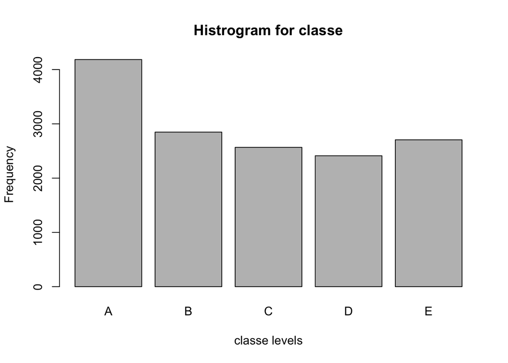

```r
plot(subTrainingData$classe, main="Histrogram for classe", xlab="classe levels", ylab="Frequency")
```

The figure shown above illustrates while the classe variables B,C,D,E are similar in frequency, the classe variable A (frequency>4000) is signficantly higher than all the other classe variables.